# Lab_4

**Part 3**

1.Find which states do the ISU defensive and offensive players come from. Create an appropriate summary.

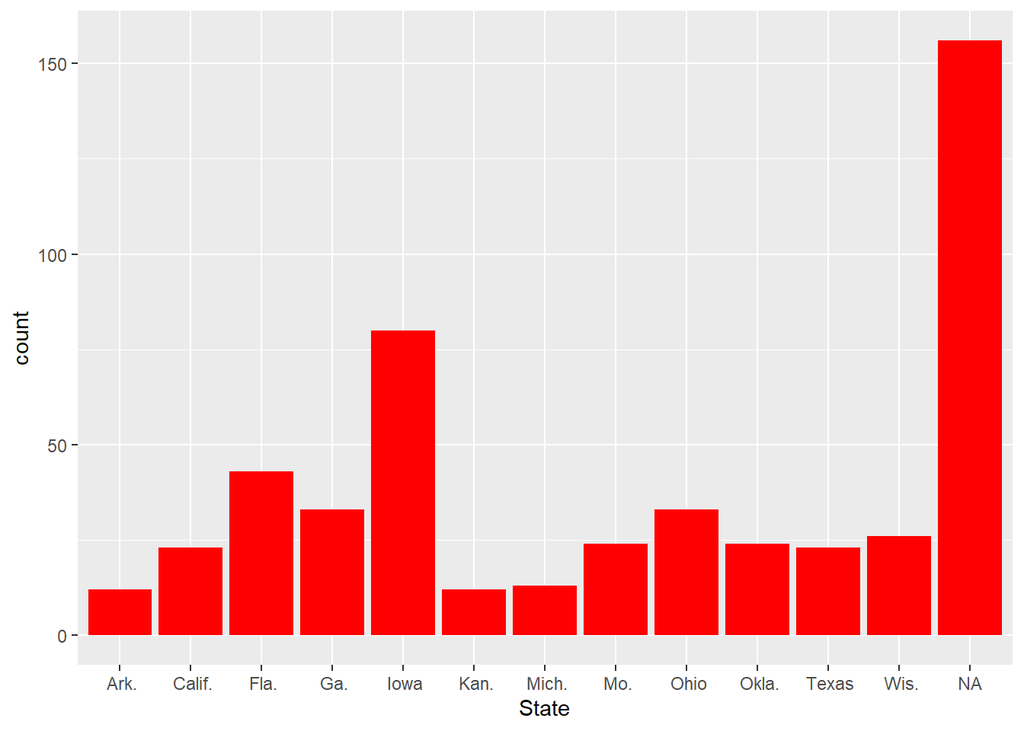

```r
#Defensive Players
Def_Bio <- left_join(defClean,BioClean, by = 'Name')
ggplot(Def_Bio, aes(x=State), width = 225) + geom_bar(fill = 'red')
```

```r
# Add to analysis, its not a good representation because the Brock is inconsistent but when you have a whole team it evens things out.
```

Defensive Response: According the graph, it appears that most of the defensive players come from Iowa, Florida, Georgia, and Ohio.

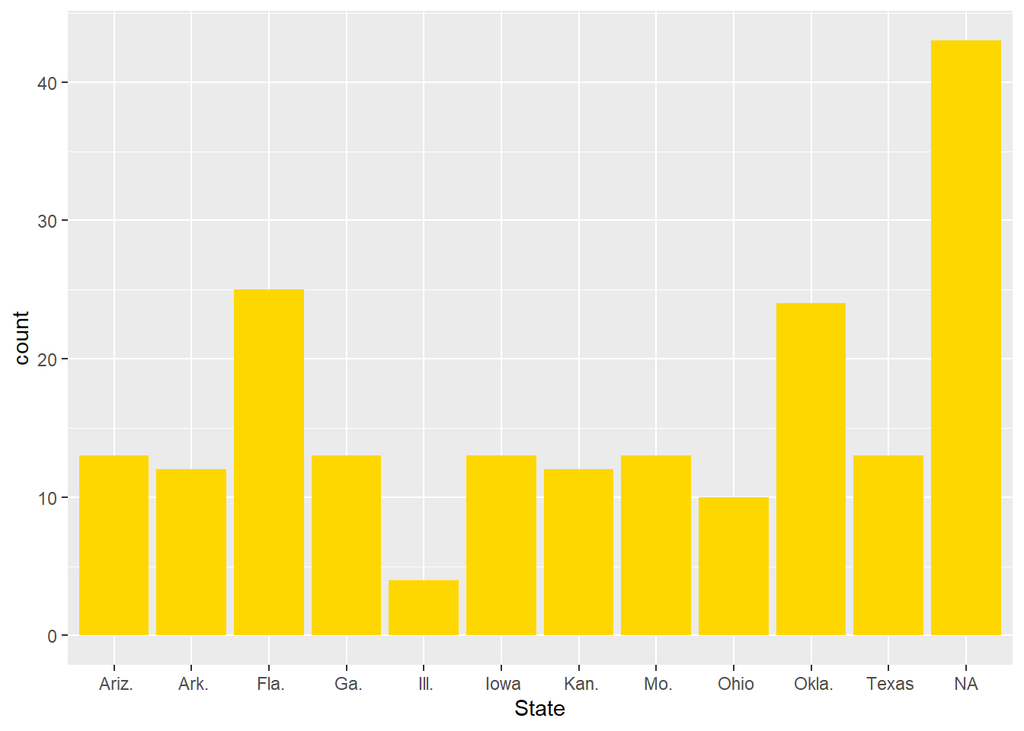

```r
Off_Bio <- left_join(OffClean,BioClean, by = 'Name')
ggplot(Off_Bio, aes(x=State), width = 225) + geom_bar(fill = 'gold')
```

Offensive Response: In this graph, we have the information regarding the players on offense and where they are from. By investigating the graph, we can see that most of these players are from Florida, Oklahoma, and there appears to be a bit of a tie between Arizona, Georgia, Iowa, Missouri, and Texas.

2. How does the performance of quarterback Brock Purdy relate to the performance of the ISU team?

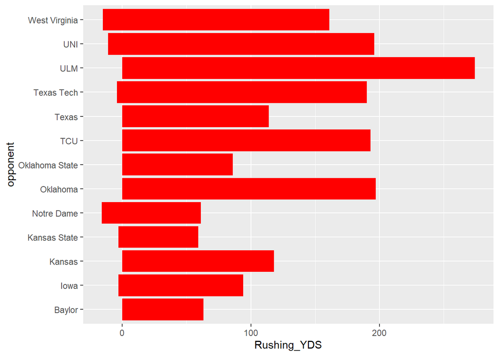

```r
Purdy <- Off_Bio %>% subset(Name == 'Purdy, Brock')
ggplot(OffClean, aes(x = Rushing_YDS,y = opponent), width = 250) + geom_col(fill = 'red')
```

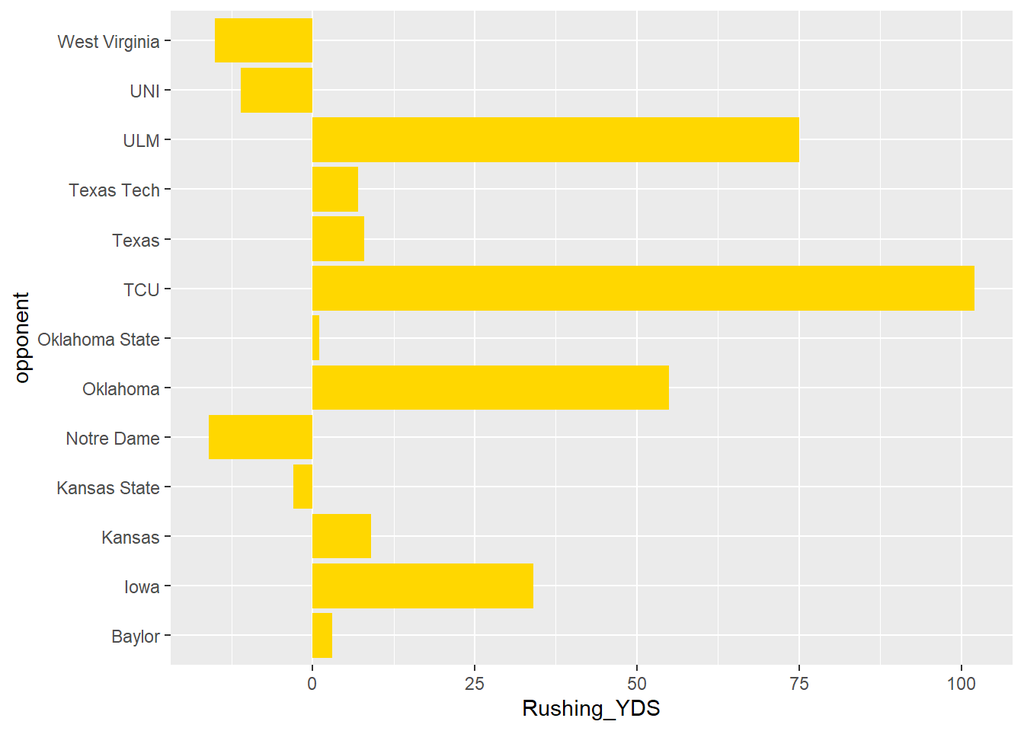

```r
ggplot(Purdy, aes(x = Rushing_YDS,y = opponent), width = 250) + geom_col(fill = 'gold')
```

3. Which ISU player(s) made big progress over the last year? Compare the 2019 and the 2018 data here.

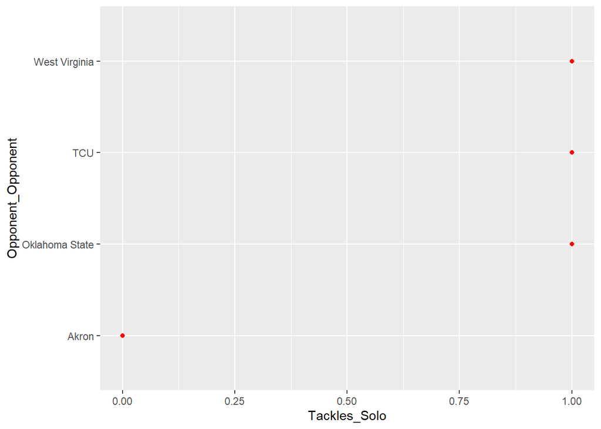

```r
defense_2018 <- read_excel('cyclonesFootball2018.xlsx' ,sheet = 'Defensive')
offense_2018 <- read_excel("cyclonesFootball2018.xlsx", sheet = 'Offensive')
biography_2018 <- read_excel('cyclonesFootball2018.xlsx', sheet = 'Biography')

Mcdonald_2019 <- defClean %>% subset(c(Name == 'McDonald, Will'))
Mcdonald_2018 <- defense_2018 %>% subset(c(Name == 'McDonald, Will'))


Mcdonald_2018['Tackles_Solo'] <- as.numeric(c(Mcdonald_2018$Tackles_Solo))
Mcdonald_2019['Tackles_Solo'] <- as.numeric(c(Mcdonald_2019$Tackles_Solo))

ggplot(Mcdonald_2018,aes(x=Tackles_Solo, y=Opponent_Opponent, width = 350)) + geom_point(color='red')
```

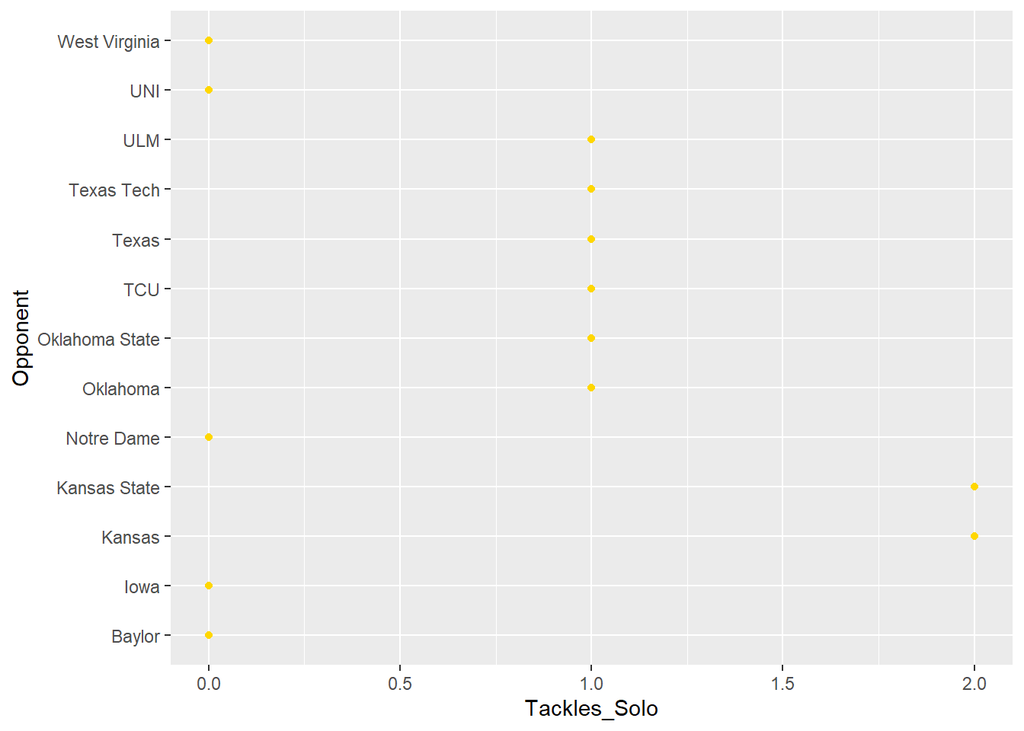

```r
ggplot(Mcdonald_2019,aes(x=Tackles_Solo, y=Opponent, width = 350)) + geom_point(color='gold')
```

When approaching this question, I did reach out to outside resources to get a better idea of who the returners are for the 2019 season. I decided to focus on the defense side and the player I choose to look at was Will McDonald. He was freshman in 2018 and played very little during that season(seen in the red graph). Moving into his sophomore season he increase his game play from 4 games to playing in all of the games for the seasons. In more than half of the games, he was able to complete at least one solo tackle in more than half of the games in the 2019 season. Therefore, I believe that Will McDonald has seen some of the best progress from 2018 to 2019.